# Part II - Prosper Loan Data Exploration

## Dataset Overview

his dataset is financial dataset and this is related to the loan, borrowers, lenders, interest rates... Prosper or Prosper Marketplace Inc. is a San Francisco, California based company specializing in loans at low interest rates to the borrowers. The dataset is comprised of 81 variables and contains 113937 entries.

## Visualization 1: "LoanStatus: Completed vs Defaulted"

We can see that there is a trend in the of LoanStatus of Completed and Defaulted

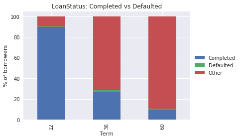

## Visualization 2: Loan for experienced people

We can see that the more experience people gain on the job, the less likely they are to choose to borrow.

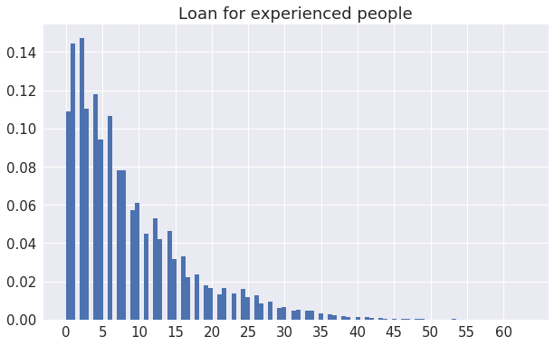

## Visualization 3: Interest Rate distribution

We can see that borrowers with poor prospects are subject to higher interest rates than borrowers with better prospects.

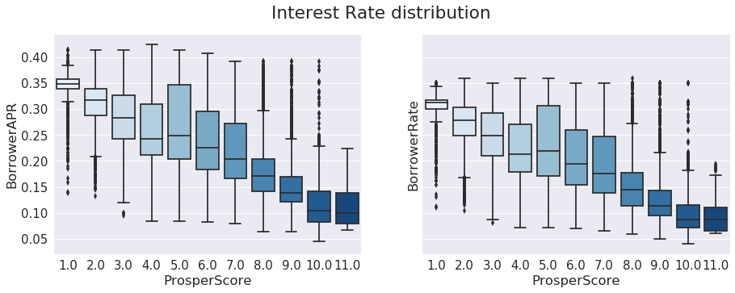

## Visualization 4: Heatmap Correlation values

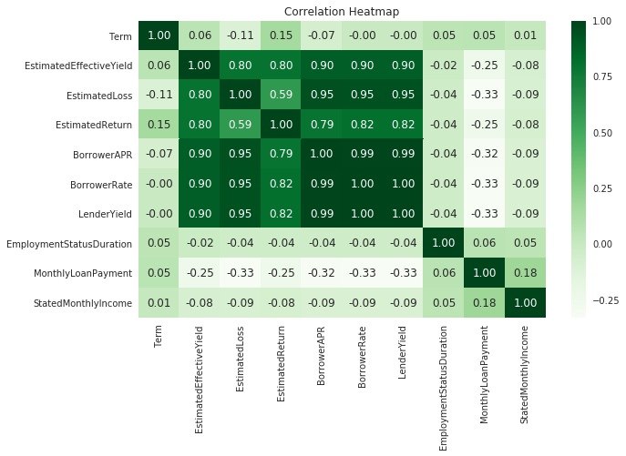

### Submission

If you are using classroom workspace, you can choose from the following two ways of submission:

1. **Submit from the workspace**. Make sure you have removed the example project from the /home/workspace directory. You must submit the following files:
   - Part_I_notebook.ipynb
   - Part_I_notebook.html or pdf
   - Part_II_notebook.ipynb
   - Part_I_slides.html
   - README.md
   - dataset (optional)
1. **Submit a zip file on the last page of this project lesson**. In this case, open the Jupyter terminal and run the command below to generate a ZIP file.

   ```
   zip -r my_project.zip .
   ```

   The command abobve will ZIP every file present in your /home/workspace directory. Next, you can download the zip to your local, and follow the instructions on the last page of this project lesson.